# handling_categorical

```python
import pandas as pd
from sklearn.model_selection import train_test_split
from sklearn.preprocessing import OneHotEncoder, OrdinalEncoder
from sklearn.compose import ColumnTransformer
from sklearn.pipeline import Pipeline
from sklearn.ensemble import RandomForestClassifier
from sklearn.metrics import accuracy_score
import matplotlib.pyplot as plt
import seaborn as sns
```

### Data Collection

```python
import requests

# URLs of the files
data_url = 'https://www.raphaelcousin.com/modules/data-science-practice/module5/course/module5_course_handling_categorical.csv'

# Function to download a file
def download_file(url, file_name):
    response = requests.get(url)
    response.raise_for_status()  # Ensure we notice bad responses
    with open(file_name, 'wb') as file:
        file.write(response.content)
    print(f'Downloaded {file_name} from {url}')

# Downloading the files
download_file(data_url, 'module5_course_handling_categorical.csv')
```

```
Downloaded module5_course_handling_categorical.csv from https://www.raphaelcousin.com/modules/data-science-practice/module5/course/module5_course_handling_categorical.csv
```

```python
df = pd.read_csv("module5_course_handling_categorical.csv", sep=",")
```

## Data Analysis

```
  class cap-diameter cap-shape cap-surface  stem-width has-ring
0     e         Tiny    Convex       Hairy        6.58        f
1     e         Tiny    Convex         Dry       33.89        f
2     e         Tiny      Flat       Silky       17.44        t
3     e         Tiny      Flat       Hairy        3.72        f
4     p         Tiny      Bell    Textured        6.08        t
<class 'pandas.core.frame.DataFrame'>
RangeIndex: 6106 entries, 0 to 6105
Data columns (total 6 columns):
 #   Column        Non-Null Count  Dtype
---  ------        --------------  -----
 0   class         6106 non-null   object
 1   cap-diameter  6106 non-null   object
 2   cap-shape     6106 non-null   object
 3   cap-surface   6106 non-null   object
 4   stem-width    6106 non-null   float64
 5   has-ring      6106 non-null   object
dtypes: float64(1), object(5)
memory usage: 286.3+ KB
None
Categorical columns: ['class', 'cap-diameter', 'cap-shape', 'cap-surface', 'has-ring']
class                                                      [e, p]
cap-diameter    [Tiny, Moderate, Small, Medium, Fairly Large, ...
cap-shape       [Convex, Flat, Bell, Sunken, Others, Punctate,...
cap-surface     [Hairy, Dry, Silky, Textured, Grooved, Wrinkle...
has-ring                                                   [f, t]
dtype: object
```

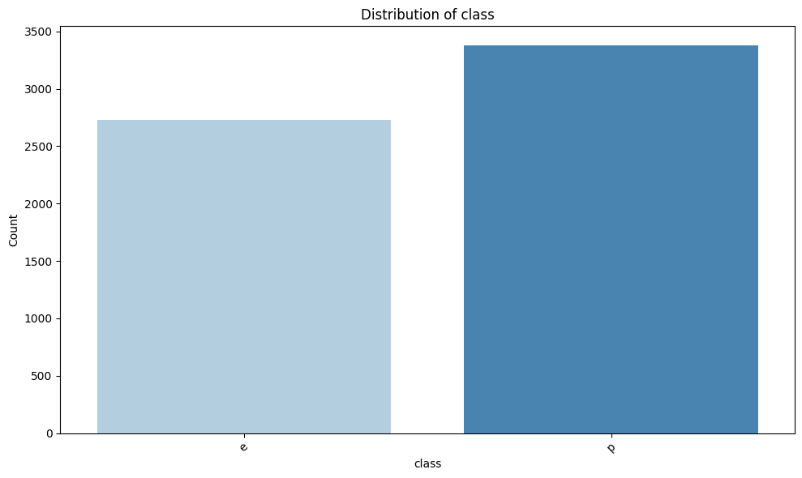

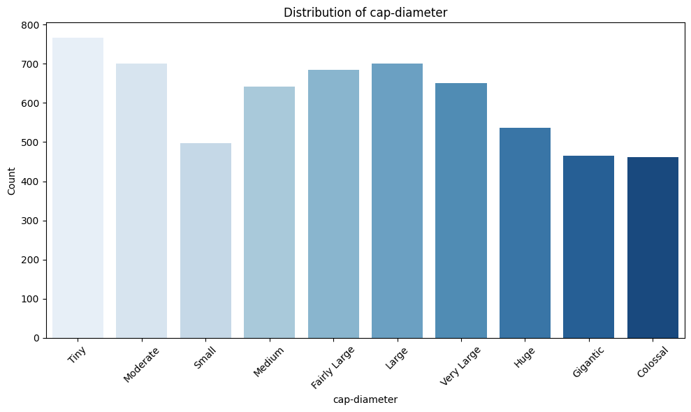

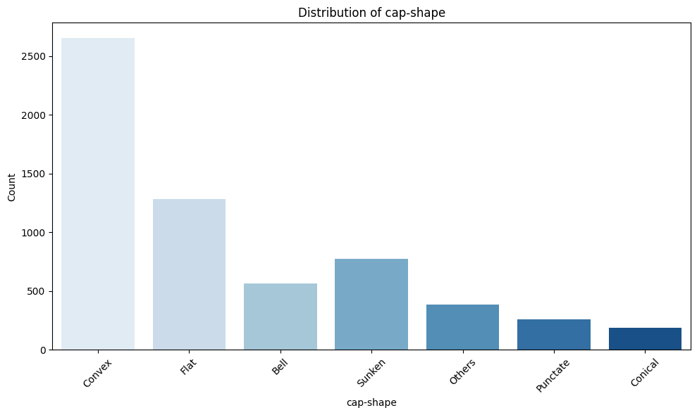

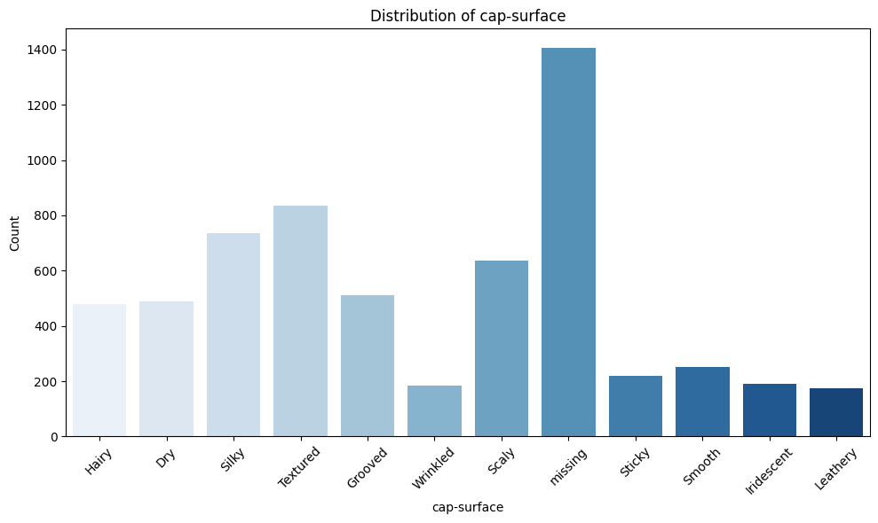

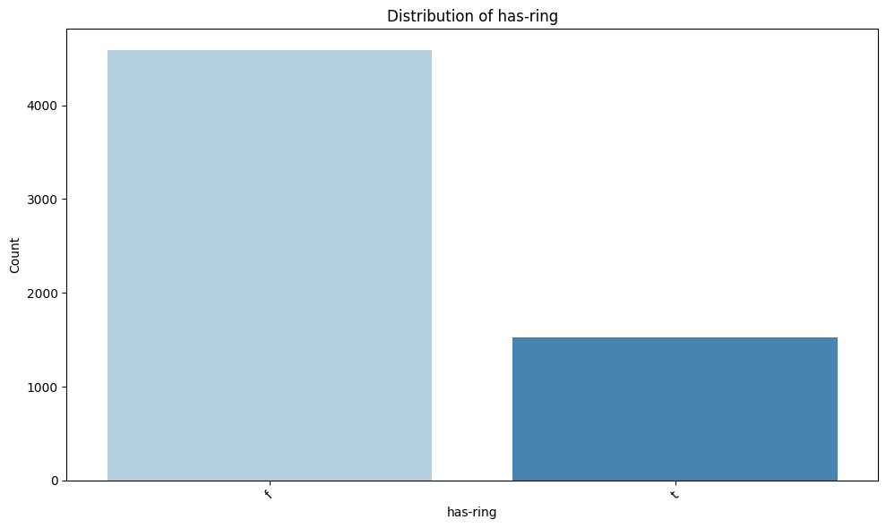

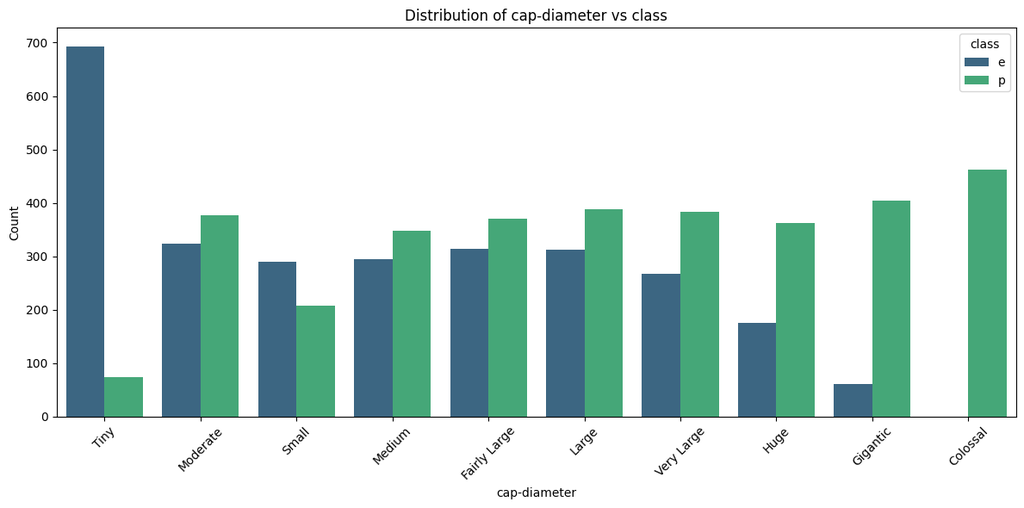

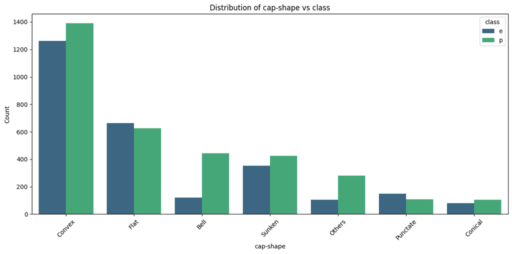

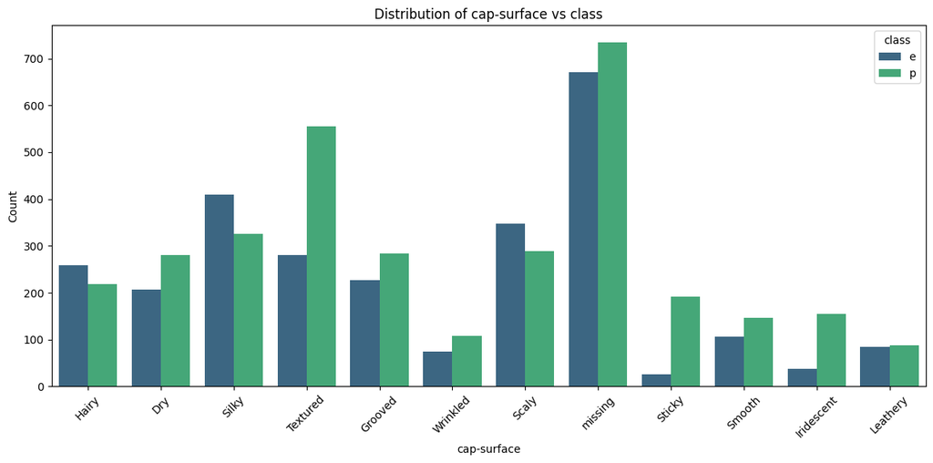

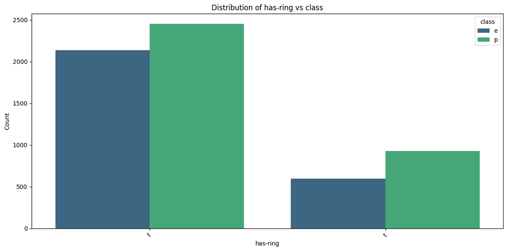

```python
print(df.head())
print(df.info())

# Identify categorical columns
categorical_columns = [col for col in df.columns if df[col].dtype == 'object' or df[col].nunique() < 11]
print("Categorical columns:", categorical_columns)

# Display unique values in categorical columns
print(df[categorical_columns].apply(lambda x: x.unique()))

# Data Visualization
def plot_categorical_distributions(df, categorical_columns):
    for col in categorical_columns:
        plt.figure(figsize=(10, 6))
        sns.countplot(x=col, data=df, palette='Blues')
        plt.title(f'Distribution of {col}')
        plt.xlabel(col)
        plt.ylabel('Count')
        plt.xticks(rotation=45)
        plt.tight_layout()
        plt.show()

def plot_categorical_vs_target(df, categorical_columns, target_column):
    for col in categorical_columns:
        if col != target_column:
            plt.figure(figsize=(12, 6))
            sns.countplot(x=col, hue=target_column, data=df, palette='viridis')
            plt.title(f'Distribution of {col} vs {target_column}')
            plt.xlabel(col)
            plt.ylabel('Count')
            plt.xticks(rotation=45)
            plt.legend(title=target_column)
            plt.tight_layout()
            plt.show()

plot_categorical_distributions(df, categorical_columns)
plot_categorical_vs_target(df, categorical_columns, 'class')
```

## Data Cleaning - Handling Categorical

1. **Handling Unseen Categories**: This method implements an OrdinalEncoder for each categorical column in a dataset, ensuring that unseen categories encountered during model testing do not cause errors by assigning them a default encoded value. This approach maintains data consistency between training and testing phases.

Mapping for 'cap-diameter': Colossal: 0 Fairly Large: 1 Gigantic: 2 Huge: 3 Large: 4 Medium: 5 Moderate: 6 Small: 7 Tiny: 8 Very Large: 9

What is the issue with this encoding?

2. **Simple One-Hot Encoding**: This approach uses one-hot encoding for categorical variables without any ordinal significance. It transforms categories into binary features, avoiding any ordinal assumptions and is suitable for nominal data where no inherent order is present.
3. **Mixed Encoding Strategy**: Combines one-hot encoding for nominal categories with ordinal encoding for ordinal categories. This method differentiates between types of categorical data, applying the most appropriate encoding technique to each, thus preserving the ordinal information where it is relevant.
4. **Ordered Ordinal Encoding**: This method explicitly defines the order of categories for ordinal data before encoding. It is crucial for models that benefit from the ordinal relationship, as it ensures that the numerical representation reflects the inherent order of the categories, potentially improving model performance by preserving this information.

Mapping for 'cap-diameter': Tiny: 0 Small: 1 Moderate: 2 Medium: 3 Fairly Large: 4 Large: 5 Very Large: 6 Huge: 7 Gigantic: 8 Colossal: 9

```
Fold 1
  Simple Encoding: 0.6457
  Simple One-Hot Encoding: 0.7079
  Mixed Encoding Strategy: 0.6809
  Mixed Encoding with Ordered Ordinal Encoding: 0.7193

Fold 2
  Simple Encoding: 0.6282
  Simple One-Hot Encoding: 0.6765
  Mixed Encoding Strategy: 0.6749
  Mixed Encoding with Ordered Ordinal Encoding: 0.6757

Fold 3
```

```
  Simple Encoding: 0.6421
  Simple One-Hot Encoding: 0.7027
  Mixed Encoding Strategy: 0.6822
  Mixed Encoding with Ordered Ordinal Encoding: 0.7150

Fold 4
```

```
  Simple Encoding: 0.6298
  Simple One-Hot Encoding: 0.7125
  Mixed Encoding Strategy: 0.6863
  Mixed Encoding with Ordered Ordinal Encoding: 0.7117

Fold 5
```

```
  Simple Encoding: 0.6290
  Simple One-Hot Encoding: 0.6970
  Mixed Encoding Strategy: 0.6896
  Mixed Encoding with Ordered Ordinal Encoding: 0.6798
```

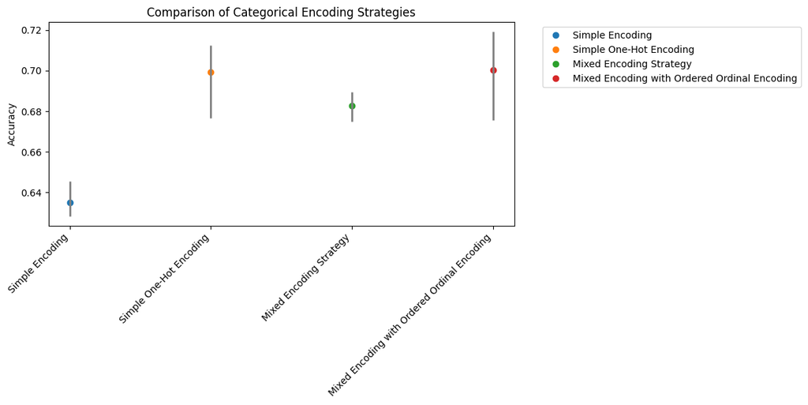

```
Final Results:
Simple Encoding:
  Mean: 0.6349
  Min: 0.6282
  Max: 0.6457

Simple One-Hot Encoding:
  Mean: 0.6993
  Min: 0.6765
  Max: 0.7125

Mixed Encoding Strategy:
  Mean: 0.6828
  Min: 0.6749
  Max: 0.6896

Mixed Encoding with Ordered Ordinal Encoding:
  Mean: 0.7003
  Min: 0.6757
  Max: 0.7193
```

```python
import pandas as pd
import numpy as np
from sklearn.model_selection import StratifiedKFold
from sklearn.preprocessing import OrdinalEncoder, OneHotEncoder
from sklearn.compose import ColumnTransformer
from sklearn.pipeline import Pipeline
from sklearn.linear_model import LogisticRegression
from sklearn.metrics import accuracy_score
import matplotlib.pyplot as plt

# Assume df is already loaded
X = df.drop('class', axis=1)
y = df['class']

# Define the number of folds for cross-validation
n_folds = 5
skf = StratifiedKFold(n_splits=n_folds, shuffle=True, random_state=42)

def fit_encode(train, test):
    encoders = {}
    for col in train.columns:
        oe = OrdinalEncoder(handle_unknown='use_encoded_value', unknown_value=-1)
        train[col] = oe.fit_transform(train[[col]])
        encoders[col] = oe
        test[col] = oe.transform(test[[col]])
    return train, test

# Define encoding strategies
strategies = {
    'Simple Encoding': OrdinalEncoder(handle_unknown='use_encoded_value', unknown_value=-1),
    'Simple One-Hot Encoding': ColumnTransformer([
        ('nom', OneHotEncoder(handle_unknown='ignore'), ['cap-shape', 'cap-surface', 'cap-diameter', 'has-ring'])
    ]),
    'Mixed Encoding Strategy': ColumnTransformer([
        ('nom', OneHotEncoder(handle_unknown='ignore'), ['cap-shape', 'cap-surface', 'has-ring']),
        ('ord', OrdinalEncoder(handle_unknown='use_encoded_value', unknown_value=-1), ['cap-diameter'])
    ]),
    'Mixed Encoding with Ordered Ordinal Encoding': ColumnTransformer([
        ('nom', OneHotEncoder(handle_unknown='ignore'), ['cap-shape', 'cap-surface', 'has-ring']),
        ('ord', OrdinalEncoder(categories=[['Tiny', 'Small', 'Moderate', 'Medium', 'Fairly Large',
                                            'Large', 'Very Large', 'Huge', 'Gigantic', 'Colossal']],
                               handle_unknown='use_encoded_value', unknown_value=-1), ['cap-diameter'])
    ])
}

# Initialize results dictionary
results = {name: [] for name in strategies.keys()}

# Perform cross-validation
for fold, (train_index, val_index) in enumerate(skf.split(X, y), 1):
    X_train, X_val = X.iloc[train_index], X.iloc[val_index]
    y_train, y_val = y.iloc[train_index], y.iloc[val_index]

    print(f"Fold {fold}")

    for name, preprocessor in strategies.items():
        if name == 'Handling Unseen Categories':
            X_train_encoded, X_val_encoded = fit_encode(X_train.copy(), X_val.copy())
            model = LogisticRegression(random_state=42)
            model.fit(X_train_encoded, y_train)
            y_pred = model.predict(X_val_encoded)
        else:
            pipeline = Pipeline([
                ('preprocessor', preprocessor),
                ('classifier', LogisticRegression(random_state=42))
            ])
            pipeline.fit(X_train, y_train)
            y_pred = pipeline.predict(X_val)

        accuracy = accuracy_score(y_val, y_pred)
        results[name].append(accuracy)
        print(f"  {name}: {accuracy:.4f}")
    print()

# Calculate statistics
stats = {name: {
    'mean': np.mean(scores),
    'min': np.min(scores),
    'max': np.max(scores)
} for name, scores in results.items()}

# Plot results
plt.figure(figsize=(12, 6))
x = range(len(strategies))
for i, (name, scores) in enumerate(results.items()):
    plt.plot(x[i], stats[name]['mean'], 'o', label=name)
    plt.vlines(x[i], stats[name]['min'], stats[name]['max'], color='gray', linestyle='-', lw=2)

plt.ylabel('Accuracy')
plt.title('Comparison of Categorical Encoding Strategies')
plt.xticks(x, list(strategies.keys()), rotation=45, ha='right')
plt.legend(bbox_to_anchor=(1.05, 1), loc='upper left')
plt.tight_layout()
plt.show()

# Print final results
print("\nFinal Results:")
for name, stat in stats.items():
    print(f"{name}:")
    print(f"  Mean: {stat['mean']:.4f}")
    print(f"  Min: {stat['min']:.4f}")
    print(f"  Max: {stat['max']:.4f}")
    print()
```